# wiki_code

**Social Network Analysis** **Network Construction**

**Dataset Selection**

For this analysis, we selected the "wiki-Vote" dataset, a public network dataset representing voting interactions on Wikipedia. This dataset was chosen due to its relevance and availability for social network analysis. Dataset Details: • Nodes: 7,066 • Edges: 103,663

**Network Construction Process**

Using Python and the NetworkX library, we constructed the social network from the "wiki-Vote" dataset. The nodes represent users, and edges indicate voting relationships between them.

**Additional Information**

**Network Analysis**

**Tools and Methods**

We employed Python, specifically the NetworkX library, for the analysis. The following analyses were conducted using both visual tools like Cytoscape and Python programming:

Degree Distribution Analysis

• Examined the distribution of node degrees in the network.

Connected Components Analysis

• Identified the largest strongly connected component for further exploration.

Path Analysis

• Calculated the average shortest path length within the largest strongly connected component.

Clustering Coefficient and Density Analysis

• Computed the clustering coefficient and network density.

Centrality Analysis

• Investigated degree centrality for each node in the network.

**Comparison with Random Graph Models**

**Open Question Exploration**

**Research Question**

Analyzing political polarization on social media platforms: To what extent does the voting network on Wikipedia exhibit political polarization, and can we identify distinct clusters based on voting patterns? Analysis Approach We plan to utilize social network analysis tools to identify and analyze clusters within the network. By examining the voting patterns, we aim to determine if there are identifiable political groups or polarization trends.

**Significance**

This research question aligns with current concerns about information dynamics and political polarization. Understanding the voting patterns on Wikipedia can provide insights into the diversity of opinions and potential echo chambers within the platform.

**Conclusion**

This comprehensive report outlines the process of constructing and analyzing the "wiki-Vote" social network dataset. The chosen analyses, comparisons with random graph models, and the proposed research question contribute to a thorough understanding of the dataset's structural properties and potential insights into political dynamics within Wikipedia's voting network.

```python
# Install required packages
!pip install networkx
!pip install numpy
!pip install matplotlib
```

```python
# Import libraries
import networkx as nx
import matplotlib.pyplot as plt
import numpy as np
import random
import tarfile
import os
from networkx.algorithms import approximation, components  # Add this line
import community
```

```python
# Load the social network graph
edges_file_path = "wiki-Vote.txt.gz"
social_graph = nx.read_edgelist(edges_file_path, create_using=nx.DiGraph)
largest_component_nodes = max(nx.weakly_connected_components(social_graph), key=len)
largest_component_graph = social_graph.subgraph(largest_component_nodes).copy()
print("Number of nodes in the largest component:", largest_component_graph.number_of_nodes())
print("Number of edges in the largest component:", largest_component_graph.number_of_edges())
```

```
Number of nodes in the largest component: 7066
Number of edges in the largest component: 103663
```

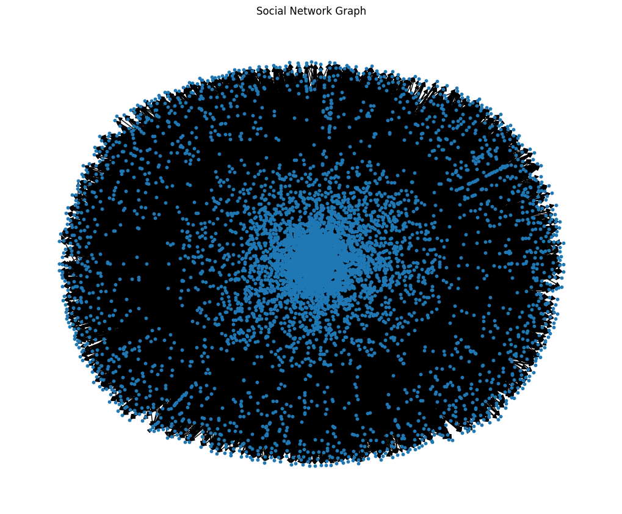

```python
# Visualize the network
plt.figure(figsize=(10, 8))
nx.draw(largest_component_graph, with_labels=False, node_size=10)
plt.title("Social Network Graph")
plt.show()
```

```python
# Use the largest strongly connected component for path analysis
largest_strongly_connected_component = max(nx.strongly_connected_components(largest_component_graph), key=len)

# Check if the largest strongly connected component is weakly connected
if nx.is_weakly_connected(largest_component_graph.subgraph(largest_strongly_connected_component)):
    path_analysis = nx.average_shortest_path_length(largest_component_graph.subgraph(largest_strongly_connected_component))
    print(f"Average Shortest Path Length in the largest strongly connected component: {path_analysis}")
else:
    print("The largest strongly connected component is not weakly connected. Adjust your approach accordingly.")

clustering_coefficient = nx.average_clustering(largest_component_graph)
density = nx.density(largest_component_graph)
centrality = nx.degree_centrality(largest_component_graph)
```

```
Average Shortest Path Length in the largest strongly connected component: 2.8792828803221413
```

```python
# Convert dictionaries to lists for slicing
degree_distribution_list = list(degree_distribution.items())
centrality_list = list(centrality.items())

# Print analysis results
print("\nDegree Distribution (First 5 records):", degree_distribution_list[:5])
print("\nDegree Centrality (First 5 records):", centrality_list[:5])

# Print scalar values
print("\nAverage Shortest Path Length:", path_analysis)
print("\nAverage Clustering Coefficient:", clustering_coefficient)
print("\nNetwork Density:", density)
```

```
Degree Distribution (First 5 records): [('30', 28), ('1412', 29), ('3352', 537), ('5254', 298), ('5543', 282)]

Degree Centrality (First 5 records): [('30', 0.003963198867657466), ('1412', 0.004104741684359519), ('3352', 0.07600849256900212), ('5254', 0.042179759377211606), ('5543', 0.03991507430997877)]

Average Shortest Path Length: 2.8792828803221413

Average Clustering Coefficient: 0.08212905643910409

Network Density: 0.0020765288717499086
```

```python
# Compare with ER, BA, and WS graphs
er_graph = nx.erdos_renyi_graph(len(largest_component_nodes), p=0.01)
ba_graph = nx.barabasi_albert_graph(len(largest_component_nodes), m=2)
ws_graph = nx.watts_strogatz_graph(len(largest_component_nodes), k=4, p=0.1)

er_degree_distribution = dict(er_graph.degree())
ba_degree_distribution = dict(ba_graph.degree())
ws_degree_distribution = dict(ws_graph.degree())
```

```python
# Convert dictionaries to lists for slicing
er_degree_list = list(er_degree_distribution.items())
ba_degree_list = list(ba_degree_distribution.items())
ws_degree_list = list(ws_degree_distribution.items())

# Print comparison results
print("\nER Graph Degree Distribution (First 5 records):", er_degree_list[:5])
print("\nBA Graph Degree Distribution (First 5 records):", ba_degree_list[:5])
print("\nWS Graph Degree Distribution (First 5 records):", ws_degree_list[:5])
```

```
ER Graph Degree Distribution (First 5 records): [(0, 60), (1, 80), (2, 71), (3, 66), (4, 69)]

BA Graph Degree Distribution (First 5 records): [(0, 248), (1, 111), (2, 2), (3, 58), (4, 258)]

WS Graph Degree Distribution (First 5 records): [(0, 4), (1, 3), (2, 3), (3, 4), (4, 4)]
```

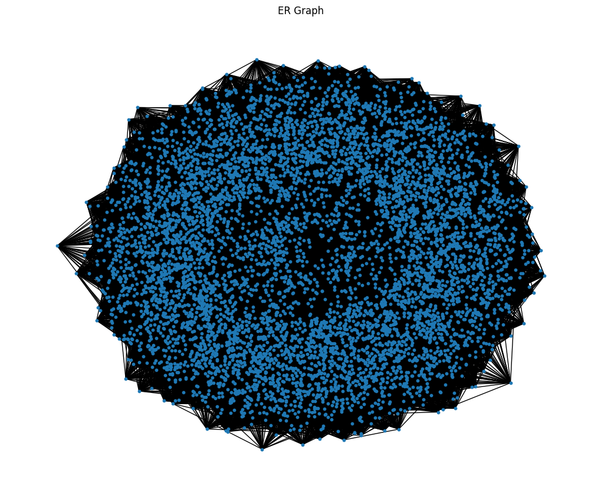

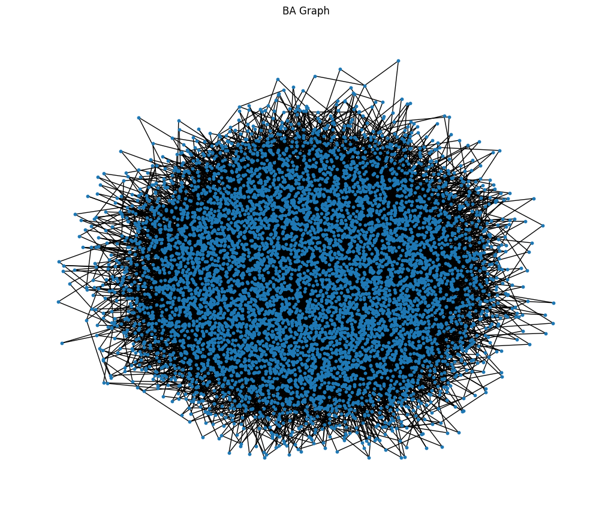

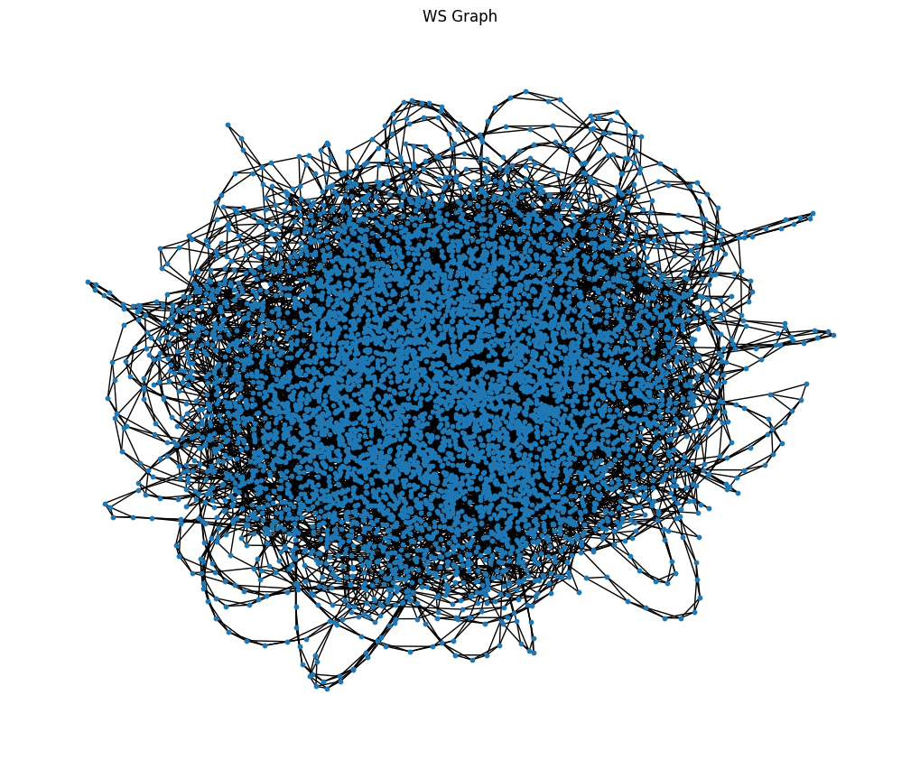

```python
# Visualize ER graph
plt.figure(figsize=(10, 8))
nx.draw(er_graph, with_labels=False, node_size=10)
plt.title("ER Graph")
plt.show()

# Visualize BA graph
plt.figure(figsize=(10, 8))
nx.draw(ba_graph, with_labels=False, node_size=10)
plt.title("BA Graph")
plt.show()

# Visualize WS graph
plt.figure(figsize=(10, 8))
nx.draw(ws_graph, with_labels=False, node_size=10)
plt.title("WS Graph")
plt.show()
```